# RMarkdown Assignment

Merry M Davidson

2/11/2020

## Instructions

This is an R Markdown document. Markdown is a simple formatting syntax for authoring HTML, PDF, and MS Word documents. For more details on using R Markdown see http://rmarkdown.rstudio.com. When you click the **Knit** button a document will be generated that includes both content as well as the output of any embedded R code chunks within the document. R Markdown can do the majority of things a typical word processing program (e.g., Microsoft Word), but requires a bit of knowledge about how the syntax works. There’s a lot of help online, but the things I tended to use most when I first started were the RMarkdown Cheat Sheet and Reference guide (got to Help > Cheatsheets inside RStudio) and the [Markdown syntax page](https://daringfireball.net/projects/markdown/syntax).

For this exercise, I want you to get comfortable using Rmarkdown to generate blogpost-style html pages that describe your project and help introduce some of the plotting techniques we learned in class. As a bonus, you’ll get to see some of the benefits of being able to write and code in one place. We’ll play with some additional approaches for producing publication-quality documents later in the semester.

## Introduce your dissertation or thesis

My work aims to assess the degree of landscape change pertaining to a savanna-forest ecotone located in southern Guyana and evalauating the dynamics between wildlife populations and this environment. The three hypothesis questions I am addressing are: Q1) How has the forest-savanna boundary changed over an eighteen-year period? Q2) How does landscape context and configuration at the forest-savanna boundary impact terrestrial wildlife communities? Q3) How does wildlife abundance impact forest dynamics at the forest-savanna boundary? Due to the overlap in habitat, this region is a biological hotspot, therefore important to conserve. For the local peoples, both habitats are used in their life hiatory and culture, and this precarious balance shifts due to drivers such as climate change (Bovolo et. al. 2012) I have 2 data sets that I will be incorporating to make a generalized linear model using R to achieve this. The 2 datasets include the remote sensed analysis of this landscape, and camera trap images to gain information on the wildlife activity that is occurring in this region.

Rodríguez, I., Albert, P., La Rose, C., Sharpe, C.J. 2011. A Study of the Use of Fire by Amerindian Communities in South Rupununi, Guyana, with recommendations for sustainable land management. Study prepared for the South Central and South Rupununi District Toshaos Councils. South Central Peoples Development Association (SCPDA), Forest Peoples Programme, UK.

Bovolo, C.I., Pereira, R., Parkin, G., Kilsby, C., Wagner, T. 2012. Fine-scale regional climate patterns in the Guianas, tropical South America, based on observations and reanalysis data. International Journal of Climatology, 32(11): 1665-1689. DOI: 10.1002/joc.2387.

For this particular assignment, I want to see if there is a difference between two raster files of a SIMILAR region in my study area. The 2 rasters are not precisely the same. Besides the areas, the main difference is that 1 raster is a composite with no augmentation, and the other is a raster generated from an NDVI greenest composite function in Google Earth Engine (for reference): https://geohackweek.github.io/GoogleEarthEngine/03-load-imagery/

## Study Area

```r
#shapefule of Guyana, in South America
guyboundary <- readOGR("C:/Users/Nessa/Desktop/BSU/SpatialDatainR_HES598/GUYdata/GUY_adm/GUY_adm1.shp")
```

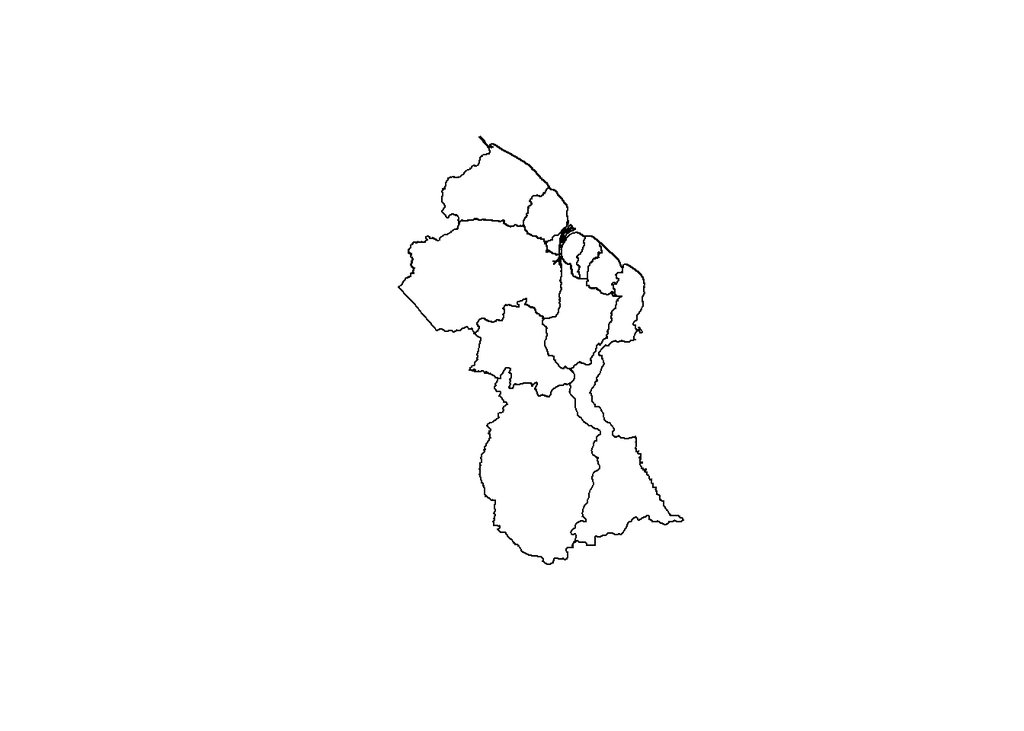

```r
plot(guyboundary)
```

```r
#no changes to the raster is landcover
landcover <- raster("C:/Users/Nessa/Desktop/BSU/SpatialDatainR_HES598/GUYdata/GUY_adm/subset2.tif")
landcover
```

```
## class      : RasterLayer
## band       : 1  (of  11  bands)
## dimensions : 1182, 1590, 1879380  (nrow, ncol, ncell)
## resolution : 0.0002694946, 0.0002694946  (x, y)
## extent     : -59.42733, -58.99883, 2.669344, 2.987886  (xmin, xmax, ymin, ymax)
## crs        : +proj=longlat +datum=WGS84 +no_defs +ellps=WGS84 +towgs84=0,0,0
## source     : C:/Users/Nessa/Desktop/BSU/SpatialDatainR_HES598/GUYdata/GUY_adm/subset2.tif
## names      : subset2
```

```r
landcover <- setMinMax(landcover)#to see min & max pixel values
landcover
```

```
## class      : RasterLayer
## band       : 1  (of  11  bands)
## dimensions : 1182, 1590, 1879380  (nrow, ncol, ncell)
## resolution : 0.0002694946, 0.0002694946  (x, y)
## extent     : -59.42733, -58.99883, 2.669344, 2.987886  (xmin, xmax, ymin, ymax)
## crs        : +proj=longlat +datum=WGS84 +no_defs +ellps=WGS84 +towgs84=0,0,0
## source     : C:/Users/Nessa/Desktop/BSU/SpatialDatainR_HES598/GUYdata/GUY_adm/subset2.tif
## names      : subset2
## values     : 57, 2654  (min, max)
```

#Visualize landcover raster

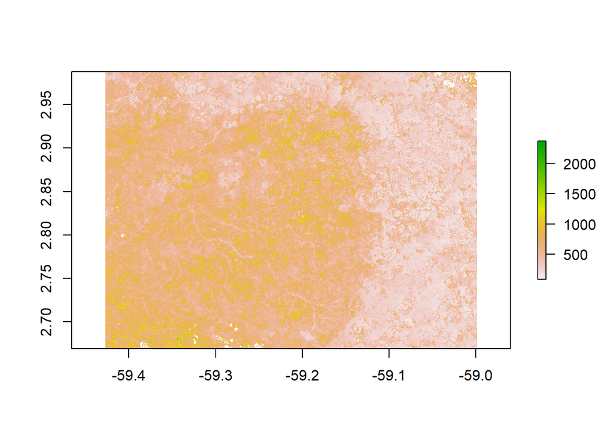

```r
plot(landcover)
```

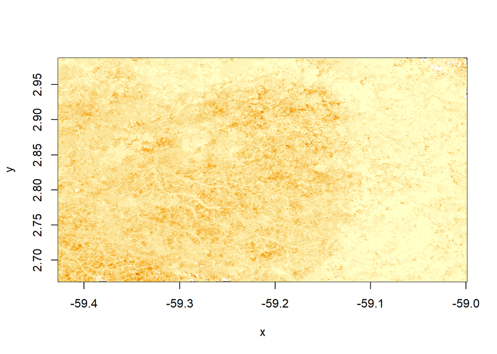

```r
image(landcover)#different way of visualizing (plot of raster)
```

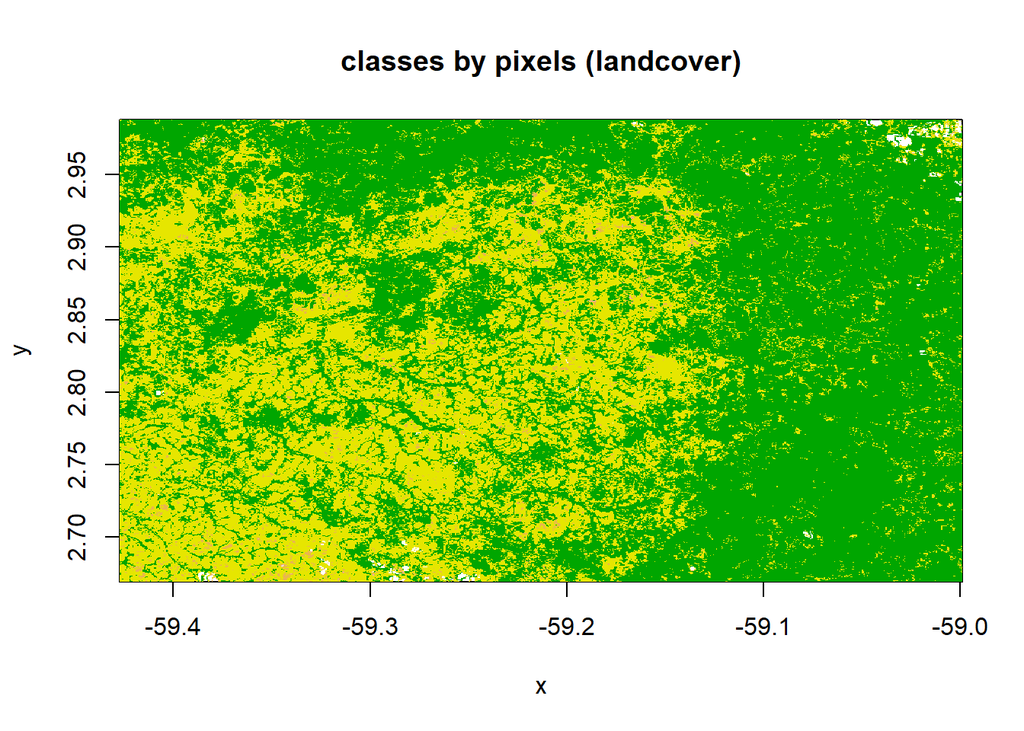

```r
# we can specify the colors too
col <- terrain.colors(5)
image(landcover, zlim=c(57,2654), main="classes by pixels (landcover)", col=col)
```

## Map an attribute of your data

After you’ve made your study area map, trying plotting some attributes of your data. Remember, there’s a lot of functionality that we haven’t explored yet so be sure to checkout the package documentation and reference webpages if you’re having trouble figuring out how to render the data you’d like to display.

I used this site as a guide:https://www.neonscience.org/raster-data-r

```r
#Greenest Composite Mosaic function is DAD1
DAD1 <- raster("C:/Users/Nessa/Desktop/BSU/RESEARCH/GUYresearch/Camera trap/DAD1/DadAnalysis/GreenCompositeYear2015_DAD.tif")
DAD1
```

```
## class      : RasterLayer
## band       : 1  (of  8  bands)
## dimensions : 928, 1743, 1617504  (nrow, ncol, ncell)
## resolution : 0.0002694946, 0.0002694946  (x, y)
## extent     : -59.61975, -59.15002, 2.768787, 3.018878  (xmin, xmax, ymin, ymax)
## crs        : +proj=longlat +datum=WGS84 +no_defs +ellps=WGS84 +towgs84=0,0,0
## source     : C:/Users/Nessa/Desktop/BSU/RESEARCH/GUYresearch/Camera trap/DAD1/DadAnalysis/GreenCompositeYear2015_DAD.tif
## names      : GreenCompositeYear2015_DAD
## values     : 0, 3634  (min, max)
```

#Visualize DAD1

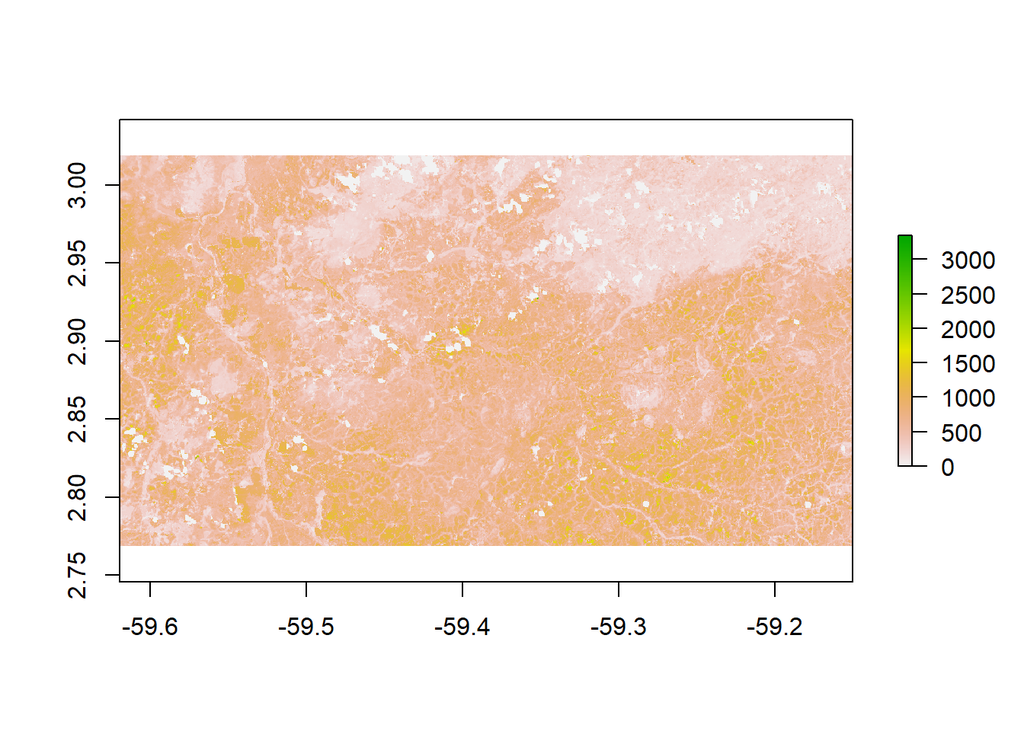

```r
plot(DAD1)
```

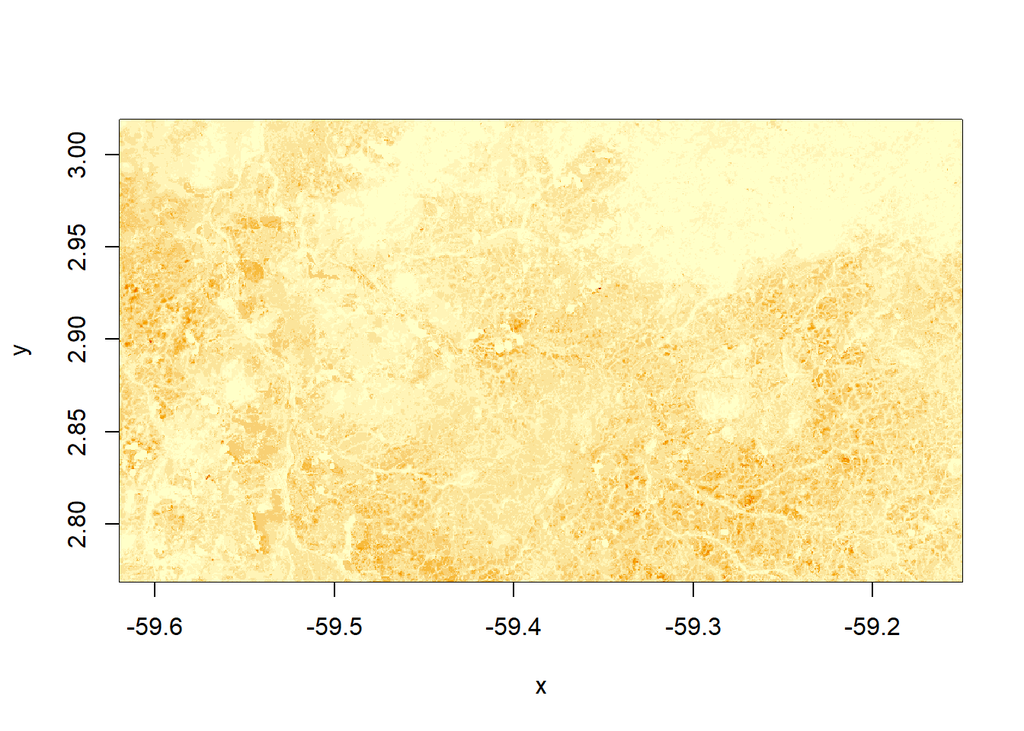

```r
image(DAD1)#different way of visualizing (plot of raster)
```

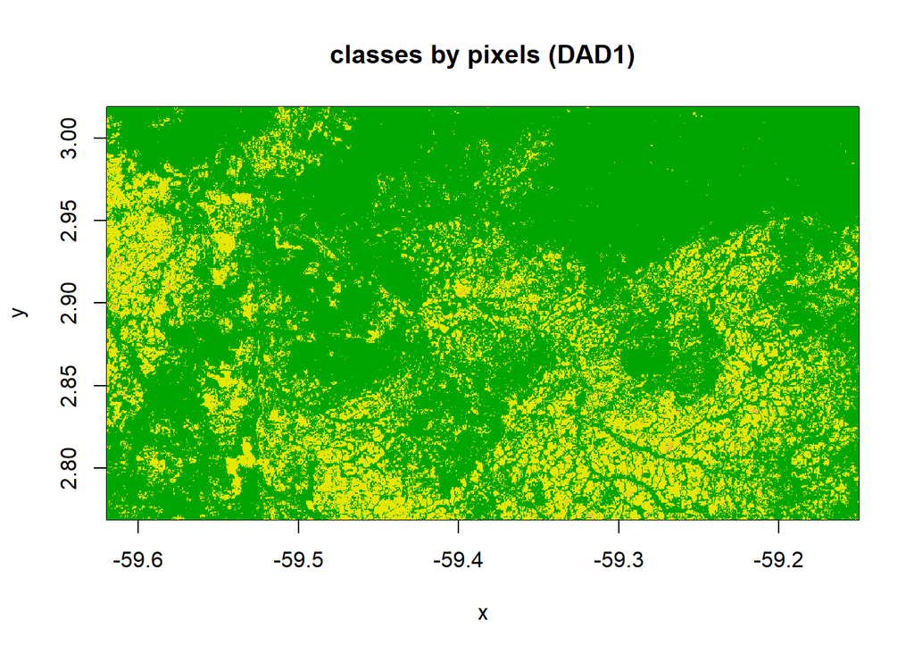

```r
# we can specify the colors too
col <- terrain.colors(5)
image(DAD1, zlim=c(0,3634), main="classes by pixels (DAD1)", col=col)
```

## Plot your data a differnt way

Throughout this course I will be encouraging you to plot your data in ways that don’t require you to generate a map. This might help you see patterns that a map might make hard to detect. It might also help you recognize that your *is* specifically tied to the spatial arrangement of your data (making maps and spatial analysis a critical component of your project). I use `ggplot2` as the primary means for generating these plots. There’s a cheatsheet available for `ggplot2` as well (got to Help > Cheatsheets inside RStudio). I also recommend [Data Visualization: A Practical Introduction by Kieran Healy](https://socviz.co). His website has the code for building the plots in his book.

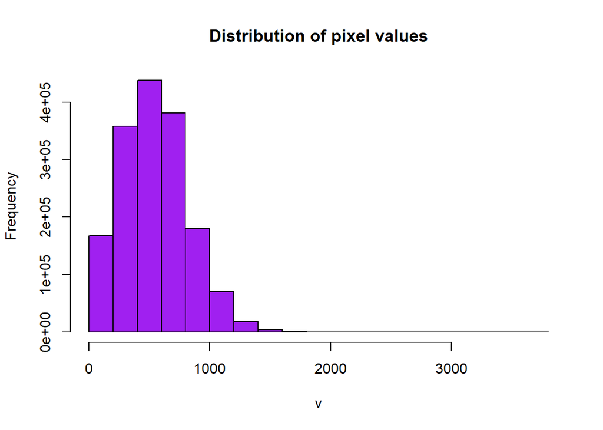

```r
##Histogram of Pixel variation of study region by greenest composite NDVI

# the distribution of values in the raster
hist(DAD1, main="Distribution of pixel values",
     col= "purple",
     maxpixels=22000000)
```

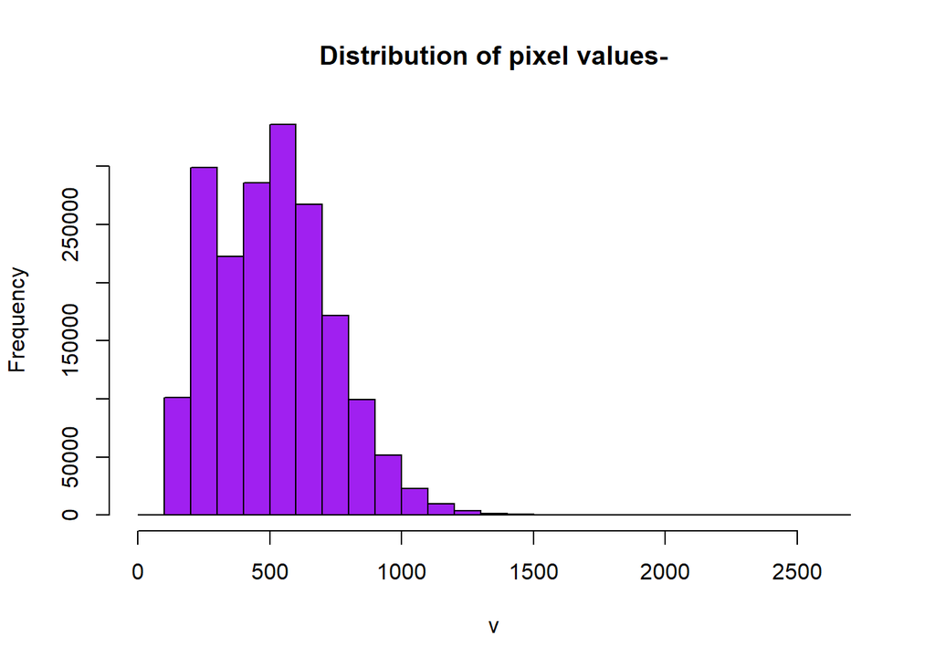

```r
####Histogram of Pixel variation of study region by no NDVI calculation
hist(landcover, main="Distribution of pixel values-",
     col= "purple",
     maxpixels=22000000)
```

## What did you learn?

This was interesting to see the differences between my raster that didn’t have a classification (landcover raster) vs the mask layer treated by greenest pixel NDVI function (DAD1 raster). Attribute tables: I noticed that there was a difference between min values by raster. Histogram plot:There was more variation in pixel distribution in the landcover raster compared to the more “normal distribution” in the DAD1 raster. I don’t think I would have noticed this difference if I didn’t plot via a histogram!

##Reflection

Comparing the variation of DAD1 and the histogram was interesting as well. Cool to learn by doing and seeing. I really learned more about the rasters via the histogrmal though. Glad I did this!